# Instrumental Variables

Neti Sheth

10/24/2020

## Objective

We want to study the relationship between healthins and medexpense, i.e., whether having health insurance reduces medical expense

```r
d <- read.csv("HealthInsurance.csv")
attach(d)
```

### Visualizations

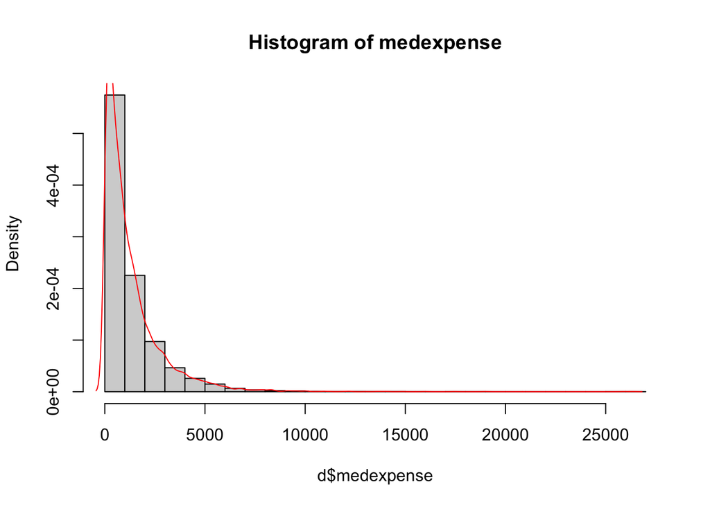

```r
hist(d$medexpense, breaks=20, prob=T, main="Histogram of medexpense")
den <- density(d$medexpense)
lines(den, col="red")
```

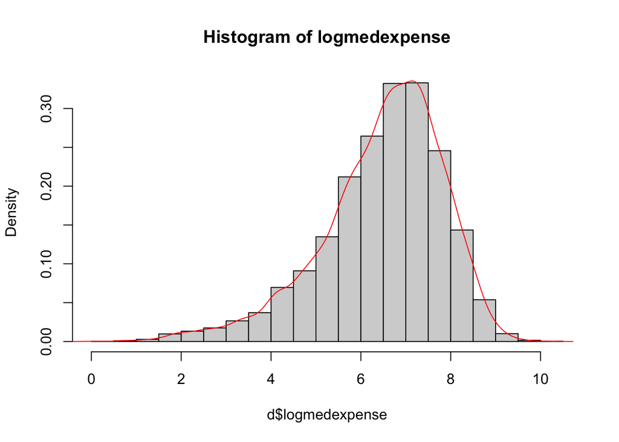

```r
hist(d$logmedexpense, breaks=20, prob=T, main="Histogram of logmedexpense")
den <- density(d$logmedexpense)
lines(den, col="red")
```

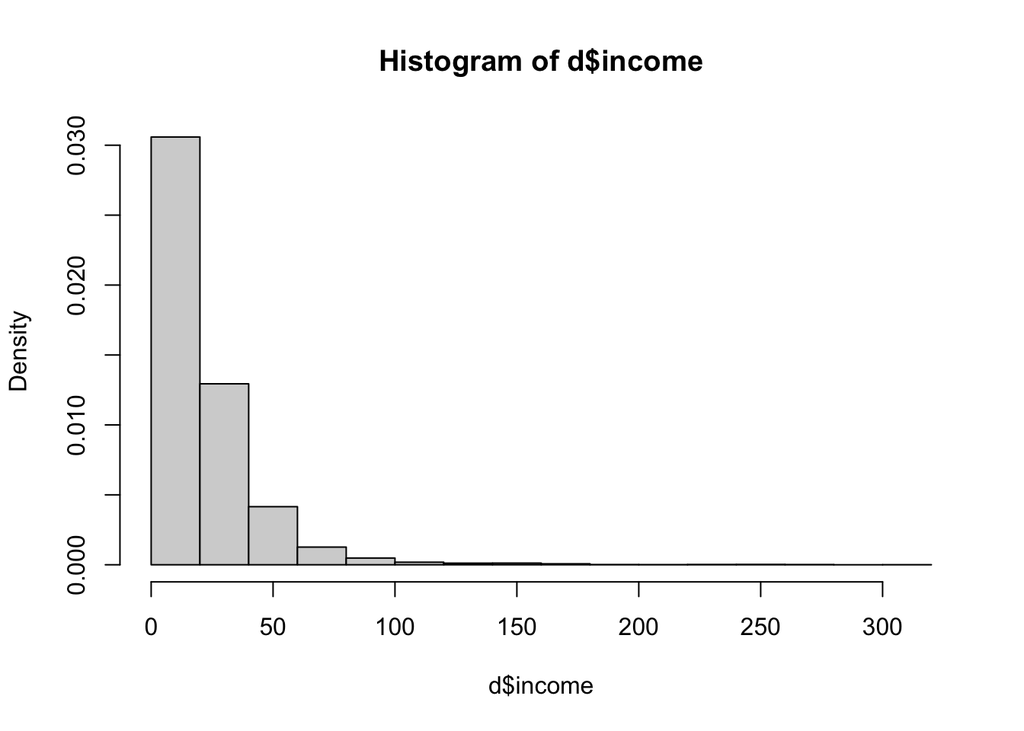

```r
hist(d$income, breaks=20, prob=T)
```

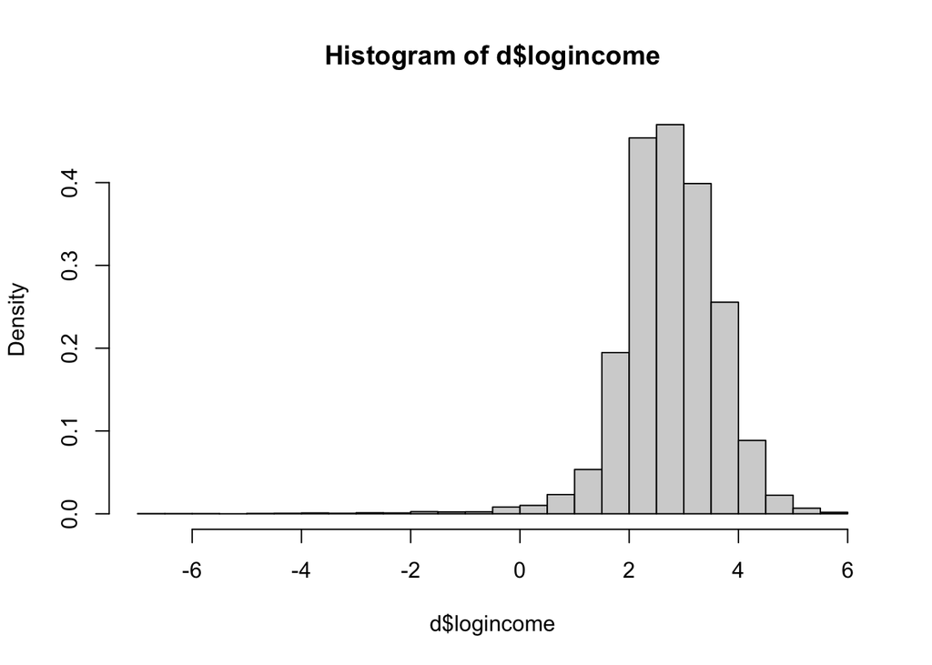

```r
hist(d$logincome, breaks=20, prob=T)
```

### Variable definition

```r
Y1 <- cbind(logmedexpense)                  # Dependent variable
Y2 <- cbind(healthins)                      # Endogeneous variable - health insurance will be y in first model and then x in the second
X1 <- cbind(illnesses, age, logincome)      # Exogeneous variable (controls)
IV <- cbind(ssiratio)                       # Instrumental variable (related to logincome)
IValt <- cbind(ssiratio, married)           # Instrumental variables, overidentified
```

```r
summary(Y1)
```

```
##  logmedexpense
##  Min.   : 0.000
##  1st Qu.: 5.740
##  Median : 6.678
##  Mean   : 6.481
##  3rd Qu.: 7.430
##  Max.   :10.180
```

```r
summary(Y2)
```

```
##    healthins
##  Min.   :0.0000
##  1st Qu.:0.0000
##  Median :0.0000
##  Mean   :0.3822
##  3rd Qu.:1.0000
##  Max.   :1.0000
```

```r
summary(X1)
```

```
##    illnesses          age          logincome
##  Min.   :0.000   Min.   :65.00   Min.   :-6.908
##  1st Qu.:1.000   1st Qu.:70.00   1st Qu.: 2.233
##  Median :2.000   Median :74.00   Median : 2.743
##  Mean   :1.861   Mean   :75.05   Mean   : 2.743
##  3rd Qu.:3.000   3rd Qu.:80.00   3rd Qu.: 3.315
##  Max.   :9.000   Max.   :91.00   Max.   : 5.744
```

```r
summary(IV)
```

```
##     ssiratio
##  Min.   :0.0000
##  1st Qu.:0.2381
##  Median :0.5045
##  Mean   :0.5365
##  3rd Qu.:0.9091
##  Max.   :9.2506
```

### OLS regression

```r
ols <- lm(Y1 ~ Y2 + X1)
summary(ols)
```

```
##
## Call:
## lm(formula = Y1 ~ Y2 + X1)
##
## Residuals:
##     Min      1Q  Median      3Q     Max
## -6.2793 -0.6768  0.1472  0.8517  3.7803
##
## Coefficients:
##              Estimate Std. Error t value Pr(>|t|)
## (Intercept)  5.780127   0.150891  38.307  < 2e-16 ***
## Y2           0.074960   0.026012   2.882  0.00396 **
## X1illnesses  0.440653   0.009572  46.035  < 2e-16 ***
## X1age       -0.002595   0.001879  -1.381  0.16735
## X1logincome  0.017236   0.013787   1.250  0.21124
## ---
## Signif. codes:  0 '***' 0.001 '**' 0.01 '*' 0.05 '.' 0.1 ' ' 1
##
## Residual standard error: 1.237 on 10084 degrees of freedom
## Multiple R-squared:  0.1749, Adjusted R-squared:  0.1746
## F-statistic: 534.4 on 4 and 10084 DF,  p-value: < 2.2e-16
```

Finding: OLS model shows that healthins INCREASES medexpense by 7.5% (note: log scale), when controlled for illnesses, age, and logincome. Is this is so, why would anyone buy healthins? Let's check for endogeneity using an instrumental variable and two stage least squares regression.

### 2SLS (2 stage least square) regression

Stage 1: Regress endogeneous variable against exogeneous and instrumental variables

```r
ols1 <- lm (Y2 ~ X1 + IV)
summary(ols1)
```

```
##
## Call:
## lm(formula = Y2 ~ X1 + IV)
##
## Residuals:
##     Min      1Q  Median      3Q     Max
## -0.6817 -0.3882 -0.2413  0.5167  2.5921
##
## Coefficients:
##               Estimate Std. Error t value Pr(>|t|)
## (Intercept)  0.9591576  0.0568776  16.864  < 2e-16 ***
## X1illnesses  0.0113510  0.0036336   3.124  0.00179 **
## X1age       -0.0085302  0.0007125 -11.973  < 2e-16 ***
## X1logincome  0.0544246  0.0056429   9.645  < 2e-16 ***
## IV          -0.1997539  0.0141579 -14.109  < 2e-16 ***
## ---
## Signif. codes:  0 '***' 0.001 '**' 0.01 '*' 0.05 '.' 0.1 ' ' 1
##
## Residual standard error: 0.4691 on 10084 degrees of freedom
## Multiple R-squared:  0.06839,    Adjusted R-squared:  0.06803
## F-statistic: 185.1 on 4 and 10084 DF,  p-value: < 2.2e-16
```

```r
Y2hat <- fitted(ols1)
```

Stage 2: Regress dependent variable against exogeneous variables and fitted values from Stage 1

```r
ols2 <- lm(Y1 ~ Y2hat + X1)
summary(ols2)
```

```
##
## Call:
## lm(formula = Y1 ~ Y2hat + X1)
##
## Residuals:
##     Min      1Q  Median      3Q     Max
## -6.2923 -0.6683  0.1525  0.8507  3.6881
##
## Coefficients:
##              Estimate Std. Error t value Pr(>|t|)
## (Intercept)  6.589839   0.221021  29.815  < 2e-16 ***
## Y2hat       -0.852201   0.186843  -4.561 5.15e-06 ***
## X1illnesses  0.448512   0.009694  46.267  < 2e-16 ***
## X1age       -0.011797   0.002627  -4.492 7.15e-06 ***
## X1logincome  0.097693   0.021157   4.617 3.93e-06 ***
## ---
## Signif. codes:  0 '***' 0.001 '**' 0.01 '*' 0.05 '.' 0.1 ' ' 1
##
## Residual standard error: 1.237 on 10084 degrees of freedom
## Multiple R-squared:  0.1759, Adjusted R-squared:  0.1756
## F-statistic: 538.1 on 4 and 10084 DF,  p-value: < 2.2e-16
```

Finding: healthins REDUCES medexpense by 85.2%, when controlled for illnesses, age, and logincome, and corrected for the endogeneous effects of ssiratio.

### ivreg

The two steps can be combined into a single equation using the ivreg() function in the AER package. Note: In ivreg() syntax, exogeneous variables X1 appears on both sides of the |, endogeneous variable Y2 appears only to the left of the |, and the IV appears only on the right. We can use ivreg(), tsls(), iv-robust() - all give similiar results

```r
#install.packages("AER")
library(AER)
ivreg <- ivreg(Y1 ~ Y2 + X1 | X1 + IV)
summary(ivreg)
```

```
##
## Call:
## ivreg(formula = Y1 ~ Y2 + X1 | X1 + IV)
##
## Residuals:
##     Min      1Q  Median      3Q     Max
## -6.7141 -0.7468  0.1288  0.8907  4.0895
##
## Coefficients:
##              Estimate Std. Error t value Pr(>|t|)
## (Intercept)  6.589839   0.234676  28.081  < 2e-16 ***
## Y2          -0.852201   0.198386  -4.296 1.76e-05 ***
## X1illnesses  0.448512   0.010293  43.575  < 2e-16 ***
## X1age       -0.011797   0.002789  -4.230 2.36e-05 ***
## X1logincome  0.097693   0.022464   4.349 1.38e-05 ***
## ---
## Signif. codes:  0 '***' 0.001 '**' 0.01 '*' 0.05 '.' 0.1 ' ' 1
##
## Residual standard error: 1.313 on 10084 degrees of freedom
## Multiple R-Squared: 0.07094, Adjusted R-squared: 0.07058
## Wald test: 477.3 on 4 and 10084 DF,  p-value: < 2.2e-16
```

### 2SLS estimation, over-identified case

A proper instrumental variable is the one that impacts dependent variable of first model and not the second one.

```r
ivreg2 <- ivreg(Y1 ~ Y2 + X1 | X1 + IValt)
summary(ivreg2)
```

```
##
## Call:
## ivreg(formula = Y1 ~ Y2 + X1 | X1 + IValt)
##
## Residuals:
##     Min      1Q  Median      3Q     Max
## -6.5062 -0.6985  0.1467  0.8559  3.7572
##
## Coefficients:
##              Estimate Std. Error t value Pr(>|t|)
## (Intercept)  6.202570   0.194517  31.887  < 2e-16 ***
## Y2          -0.408760   0.139404  -2.932  0.00337 **
## X1illnesses  0.444753   0.009804  45.366  < 2e-16 ***
## X1age       -0.007396   0.002345  -3.154  0.00161 **
## X1logincome  0.059212   0.018375   3.222  0.00128 **
## ---
## Signif. codes:  0 '***' 0.001 '**' 0.01 '*' 0.05 '.' 0.1 ' ' 1
##
## Residual standard error: 1.259 on 10084 degrees of freedom
## Multiple R-Squared: 0.1466,  Adjusted R-squared: 0.1463
## Wald test: 516.8 on 4 and 10084 DF,  p-value: < 2.2e-16
```

Finding: its atleast in the correct direction. married is a good instrumental variable. employed might be a potential variable as some employers get insurance benefits firm size might have an impact too - we can try that.

### Comparing all the models

```r
library(stargazer)
stargazer(ols, ols2, ivreg, ivreg2, type="text")
```

```
##
## ==========================================================================
##                                             Dependent variable:
##                                  -----------------------------------------
##                                                     Y1
##                                           OLS             instrumental
##                                                             variable
##                                     (1)        (2)        (3)       (4)
## --------------------------------------------------------------------------
## Y2                                0.075***             -0.852*** -0.409***
##                                   (0.026)               (0.198)   (0.139)
##
## Y2hat                                       -0.852***
##                                              (0.187)
##
## X1illnesses                       0.441***   0.449***  0.449***  0.445***
##                                   (0.010)    (0.010)    (0.010)   (0.010)
##
## X1age                              -0.003   -0.012***  -0.012*** -0.007***
##                                   (0.002)    (0.003)    (0.003)   (0.002)
##
## X1logincome                        0.017     0.098***  0.098***  0.059***
##                                   (0.014)    (0.021)    (0.022)   (0.018)
##
## Constant                          5.780***   6.590***  6.590***  6.203***
##                                   (0.151)    (0.221)    (0.235)   (0.195)
##
## --------------------------------------------------------------------------
## Observations                       10,089     10,089    10,089    10,089
## R2                                 0.175      0.176      0.071     0.147
## Adjusted R2                        0.175      0.176      0.071     0.146
## Residual Std. Error (df = 10084)   1.237      1.237      1.313     1.259
## F Statistic (df = 4; 10084)      534.365*** 538.149***
## ==========================================================================
## Note:                                          *p<0.1; **p<0.05; ***p<0.01
```

Finding: Effect decrease quite a bit compared to the previous model but remains negative.

### Hausman test for endogeneity

Comparison of coefficients between the OLS and 2SLS models. If coefficients are close, then there is no endogeneity, and we don't need 2SLS. H0: No endogeneity between OLS and 2SLS models. Reject H0 if p<0.05

```r
coef_diff <- coef(ivreg) - coef(ols)
vcov_diff <- vcov(ivreg) - vcov(ols)
x2_diff <- as.vector(t(coef_diff) %*% solve(vcov_diff) %*% coef_diff)
pchisq(x2_diff, df=2, lower.tail=FALSE)
```

```
## [1] 1.493317e-05
```

Finding: There is endogeneity in the data; hence our 2SLS model is better.

### Checking for simultaneity (using 2SLS and 3SLS) - Does healthins reduce medexpense or does medexpense reduce healthins?

We must test two alternate equations, using a "simultaneous equation model". Requires systemfit() function from SYSTEMFIT package.

```r
#install.packages("systemfit")
library(systemfit)
X2 <- cbind(illnesses)                      # Exogeneous variables for second equation
IV2 <- cbind(firmsize)                      # Instrumental variable for second equation
eq1 <- Y1 ~ Y2 + X1 + IV
eq2 <- Y2 ~ Y1 + X2 + IV2
inst <- ~ X1 + IV + IV2                     # For the system of equation, instrument includes all
                                            # exogeneous variables and IV from both equations
system <- list(eq1=eq1, eq2=eq2)            # Specify system of equations - model that 2 equations
```

### 2SLS estimation

```r
sls2 <- systemfit(system, "2SLS", inst=inst, data=d)
summary(sls2)
```

```
##
## systemfit results
## method: 2SLS
##
##            N    DF   SSR detRCov   OLS-R2 McElroy-R2
## system 20178 20168 47540 0.47777 -1.25336   0.347215
##
##         N    DF      SSR      MSE     RMSE        R2    Adj R2
## eq1 10089 10083 45160.84 4.478909 2.116343 -1.413068 -1.414264
## eq2 10089 10085  2379.12 0.235907 0.485702  0.001311  0.001014
##
## The covariance matrix of the residuals
##          eq1      eq2
## eq1 4.478909 0.760812
## eq2 0.760812 0.235907
##
## The correlations of the residuals
##          eq1      eq2
## eq1 1.000000 0.740152
## eq2 0.740152 1.000000
##
##
## 2SLS estimates for 'eq1' (equation 1)
## Model Formula: Y1 ~ Y2 + X1 + IV
## Instruments: ~X1 + IV + IV2
##
##               Estimate Std. Error  t value   Pr(>|t|)
## (Intercept)  9.1951779  1.7198465  5.34651 9.1625e-08 ***
## Y2          -3.5684797  1.7730127 -2.01266   0.044176 *
## X1illnesses  0.4793449  0.0259563 18.46738 < 2.22e-16 ***
## X1age       -0.0349679  0.0154619 -2.26155   0.023746 *
## X1logincome  0.2455253  0.0997969  2.46025   0.013901 *
## IV          -0.5425873  0.3598792 -1.50769   0.131664
## ---
## Signif. codes:  0 '***' 0.001 '**' 0.01 '*' 0.05 '.' 0.1 ' ' 1
##
## Residual standard error: 2.116343 on 10083 degrees of freedom
## Number of observations: 10089 Degrees of Freedom: 10083
## SSR: 45160.843739 MSE: 4.478909 Root MSE: 2.116343
## Multiple R-Squared: -1.413068 Adjusted R-Squared: -1.414264
##
##
## 2SLS estimates for 'eq2' (equation 2)
## Model Formula: Y2 ~ Y1 + X2 + IV2
## Instruments: ~X1 + IV + IV2
##
##                Estimate  Std. Error  t value   Pr(>|t|)
## (Intercept)  0.21943972  0.42423129  0.51726 0.60498299
## Y1           0.02812350  0.07483363  0.37581 0.70706335
## X2          -0.01116342  0.03303761 -0.33790 0.73544538
## IV2          0.00892771  0.00267620  3.33596 0.00085313 ***
## ---
## Signif. codes:  0 '***' 0.001 '**' 0.01 '*' 0.05 '.' 0.1 ' ' 1
##
## Residual standard error: 0.485702 on 10085 degrees of freedom
## Number of observations: 10089 Degrees of Freedom: 10085
## SSR: 2379.118873 MSE: 0.235907 Root MSE: 0.485702
## Multiple R-Squared: 0.001311 Adjusted R-Squared: 0.001014
```

### 3SLS estimation

```r
sls3 <- systemfit(system, "3SLS", inst=inst, data=d)
summary(sls3)
```

```
##
## systemfit results
## method: 3SLS
##
##            N    DF     SSR  detRCov    OLS-R2 McElroy-R2
## system 20178 20168 27974.9 0.406195 -0.325992   0.202747
##
##         N    DF      SSR      MSE     RMSE        R2    Adj R2
## eq1 10089 10083 25595.82 2.538512 1.593271 -0.367655 -0.368333
## eq2 10089 10085  2379.12 0.235907 0.485702  0.001311  0.001014
##
## The covariance matrix of the residuals used for estimation
##          eq1      eq2
## eq1 4.478909 0.760812
## eq2 0.760812 0.235907
##
## The covariance matrix of the residuals
##          eq1      eq2
## eq1 2.538512 0.438927
## eq2 0.438927 0.235907
##
## The correlations of the residuals
##          eq1      eq2
## eq1 1.000000 0.567196
## eq2 0.567196 1.000000
##
##
## 3SLS estimates for 'eq1' (equation 1)
## Model Formula: Y1 ~ Y2 + X1 + IV
## Instruments: ~X1 + IV + IV2
##
##                Estimate  Std. Error  t value   Pr(>|t|)
## (Intercept)  5.72733139  1.70440214  3.36032 0.00078142 ***
## Y2          -1.86632058  1.77173531 -1.05339 0.29218951
## X1illnesses  0.42696175  0.02587455 16.50122 < 2.22e-16 ***
## X1age        0.00639031  0.01525498  0.41890 0.67529807
## X1logincome -0.01772859  0.09860049 -0.17980 0.85731141
## IV           0.45069051  0.35782114  1.25954 0.20786403
## ---
## Signif. codes:  0 '***' 0.001 '**' 0.01 '*' 0.05 '.' 0.1 ' ' 1
```

[output cut: 8 more lines]

```
## Model Formula: Y2 ~ Y1 + X2 + IV2
## Instruments: ~X1 + IV + IV2
##
##                Estimate  Std. Error  t value   Pr(>|t|)
## (Intercept)  0.21943972  0.42423129  0.51726 0.60498299
## Y1           0.02812350  0.07483363  0.37581 0.70706335
## X2          -0.01116342  0.03303761 -0.33790 0.73544537
## IV2          0.00892771  0.00267620  3.33596 0.00085313 ***
## ---
## Signif. codes:  0 '***' 0.001 '**' 0.01 '*' 0.05 '.' 0.1 ' ' 1
##
## Residual standard error: 0.485702 on 10085 degrees of freedom
## Number of observations: 10089 Degrees of Freedom: 10085
## SSR: 2379.118873 MSE: 0.235907 Root MSE: 0.485702
## Multiple R-Squared: 0.001311 Adjusted R-Squared: 0.001014
```